# IE360 Project/Group6

Barış Can Okur, Furkan Efe, Pelinsu Yılmaz, Zeynep Sezer

7/5/2020

## Introduction

In the last decade, e-commerce is growing at an extraordinary pace. Trendyol is the most rapidly growing e-commerce platform in Turkey. Each day, they are selling thousands of products from different brands and categories. The environment of e-commerce is really agile and one should be able to predict the consumer behavior and act accordingly. The nature of e-commerce relies on being data-driven, and Trendyol is working on observing the available data in e-commerce and making remarkable predictions about the future. It is not easy to imagine how many active users Trendyol has, and how many transactions there are just in one day. In order to manage this complexity, Trendyol has to constantly analyse their data and make predictions for the future. In this project, a forecasting method will be developed in order to make reliable predictions for the sales of eight different products. These predictions might be dependent on many factors such as pricing, basket count, favorite count. The project is a real time project and the forecasts are done each day for the next day’s sales quantity. The forecasts should be reliable in order to avoid opportunity losses and provide customer satisfaction. Therefore, the forecast model will be formed by analyzing the past data deeply for each product separately.

As discussed above, there are eight products to be forecasted and each are from different categorical levels, brands and site levels. In Table 1, the list of products that will be predicted and their hierarchical details can be found.

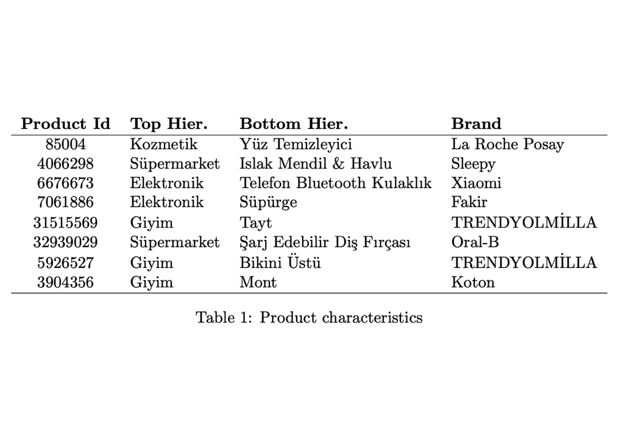

The data set provided by Trendyol includes all information regarding these products: sales quantity, price, favored counts, basket count etc. This data is updated on a daily basis, so each day, the last day’s data becomes available for more accurate forecasting. In the data set some information is missing which might lead to redundant variations for the data. Data manipulation is done in order to avoid such variations.

## Literature Review

Product demand forecasting has been done in many different ways in the literature. The simplest way is time series regression models. Time series regression model is predicting the future of a time series based on another time series. yt is the forecast variable and xtis the predictor variable.

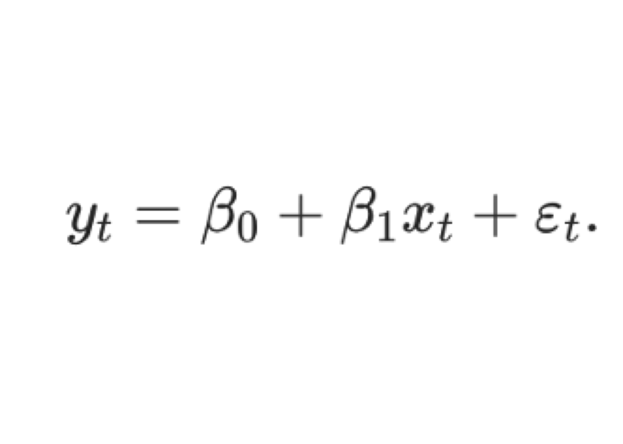

Time Series decomposition is another approach to product forecasting. The patterns such as seasonality, trends and cycles are decomposed from the data. The forecast is done separately for each component and then summed up for the final product forecast. yt is the forecast variable, St is the seasonality component, Tt is the trend component and the remaining component is called Rt.

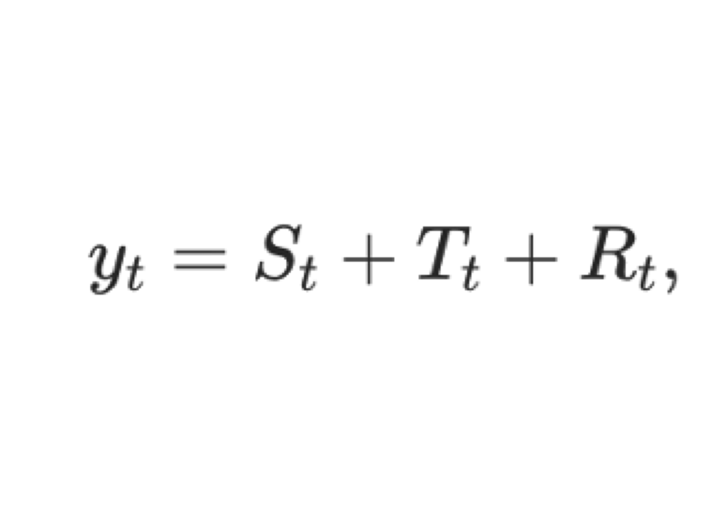

Another forecasting method is exponential smoothing. This method uses the weighted average of the last observations, recent ones having more weight. This method is widely used and quick to generate forecasts.

ARIMA model is another commonly used forecasting method. ARIMA models focus on the explanation of the autocorrelations in the data. Arima models are formed based on lagged observations and lagged errors of the past data. In order to use the arima model, the series must be stationary.

Lastly, if the forecasting is done at a higher hierarchical level, not at the SKU level, hierarchical forecasting can be used. This approach can be applied in three different ways: top-down approach, bottom-up approach, middle-out approach. As the names suggest, in the top-down approach first the forecast for the highest level is done and branched down into SKU level. In the bottom-up approach, the forecast is done in SKU level, then generalized to the highest hierarchical level. For the middle-out approach, a middle level is specified and for the levels below middle level top-down approach, for the ones above bottom-up approach are used.

## Approach

In this project, we mainly used two different approaches to forecast Trendyol’s sales for 8 different products in different categories. The two main methods are decomposition and ARIMA models.

#### 1) ARIMA Models

Before applying ARIMA models to predict future sales, we needed to first split the data into different products and create eight different xts objects for each product so that working with these xts objects are much more comfortable than data.frame objects. Then, cleaning the data is necessary because the data has many missed entries. Manipulating data for price was also needed to improve the ARIMA model using price as a regressor, so price was changed as the mean of the prices of 1 day ago and 1 day later. Afterwards, we separated each product data into parts so that we can train and test our model on different parts. We used different ARIMA models to forecast different product sales. All models were checked for residuals to have no high autocorrelation and to be normally distributed. In addition, we have tried many different ARIMA models to forecast one product and compared their AICc values to see which model is a better fit more than others. Also, we have added different regressors separately such as price, basket count, favored count, visit count to our ARIMA models to predict sales of the future. Changing the extent of the regressors such as giving the regressor of the favored count of the mean of the last 3 to 5 days decreased the AICc values of the ARIMA models. However, these regressors don’t always improve the forecasts, so the trial and error method was used to decide whether to include those into the model or not. Ensembling different ARIMA models were at the table for better predictions. We gave weights for different models to combine them into a new ensembled model. We decided the weight of the models by comparing their test results. We also calculated the MAPE and MAE values on the test sets to improve our comparison between different models.

#### 2) Decomposition of Trend and Seasonality

Decomposing seasonality and trend from the original data set, then forecasting the 3 components separately is our second approach. Differently from the first approach, the separated data for each product is converted into a data.table object. We look for the best decomposition method and according to the AICcs values generally additive decomposition method succeeded better than multiplicative one. We used Linear Regression to extract trends from the data set, also Fourier series used to extract and predict the seasonality. Similarly we compute the test results and values of MAPE and MAE.

In the last phase of the project, according to the MAPE values of the test results, we gave weights to each approach and combined them to predict sales better. So, the final prediction is an ensemble of decomposition and arima model with certain weights.

## Results

The forecast is consistent for the products that are not affected either by sales price or the season such as the face cleanser and leggings. However the forecast for products such as vacuum cleaners or headphones are less accurate due to changing technology trends, advertising trends and exchange rates. As discussed earlier since these effects are not taken into account, the mean absolute error is higher.

For products like coats and bikinis since they have strong seasonality on yearly basis the forecast was mostly zero. The live forecasting took place in early spring so it is logical to not have demand for those products in the given period. We have not computed the mean absolute percentage error because mean absolute percentages for both products were infinite. Mean absolute errors were already really low, therefore they were not suitable for comparison. Therefore, we focused more on the other products with more fluctuating demands.

As observed from the data, e-commerce sales are not easy to interpret rather they are complicated. There are so many factors affecting online sales including social media promotions. In this project we were limited with some major effects however the real life is much more complicated. It was not possible to fully demonstrate the fluctuating demand with the generated model. Even though we have tried to reduce the mean absolute percentage error, it was still not sufficient to form the perfect model.

It is believed that if our model is run for a long time, then the weights of the two models can be adjusted better and the fluctuating demand may be forecasted in a more precise way. Also, forecasting the sales with our model and keeping forecast errors would be beneficial in the long run.

## Conclusion and Future Work

As can be seen in the literature review, there are many approaches to forecasting a products’ demand. In our approach, we tried to combine these different methods to come up with the best forecast. However, it is still a fact that modeling the real world is not easy since there are many factors affecting each situation.

To improve our forecasting model, we can incorporate some external factors using different data sources. For example, for vacuum cleaners and headphones, we can add a Google trends data to see the trend for these categories. Since these products are mostly imported from other countries, the currency rates can also be added as regressors. Also, in the technology category another thing to be aware of is the new launches. If there is a new generation of the same product, we might expect the sales to go down.

In the clothing category, since Trendyol is well-known for its influencer marketing on social media, that can also be incorporated into our model. For example, we could analyze the data of the products that were advertised by the influencers and how it affected the sales, then we could add that effect to our model (if the product is advertised in the given period).

It is not possible to model the real world completely, however with the right weights to each effect, the model can become more realistic and reliable.

## References

Hyndman, Rob J. “Forecasting in R.” DataCamp, http://learn.datacamp.com/courses/forecasting-in-r.

LaBarr, Aric. “Forecasting Product Demand in R.” DataCamp, http://learn.datacamp.com/courses/forecasting-product-demand-in-.

Hyndman , Rob J, and George Athanasopoulos. “Forecasting: Principles and Practice.” Otexts, http://otexts.com/fpp2/MA.html.

## Code

Here is our code.

```r
# install the required packages first

require(jsonlite)
require(httr)
require(data.table)
require(xts)
require(forecast)
require(ggplot2)

get_token <- function(username, password, url_site){

  post_body = list(username=username,password=password)
  post_url_string = paste0(url_site,'/token/')
  result = POST(post_url_string, body = post_body)

  # error handling (wrong credentials)
  if(result$status_code==400){
    print('Check your credentials')
    return(0)
  }
  else if (result$status_code==201){
    output = content(result)
    token = output$key
  }

  return(token)
}

get_data <- function(start_date='2020-03-20', token, url_site){

  post_body = list(start_date=start_date,username=username,password=password)
  post_url_string = paste0(url_site,'/dataset/')

  header = add_headers(c(Authorization=paste('Token',token,sep=' ')))
  result = GET(post_url_string, header, body = post_body)
  output = content(result)
  data = data.table::rbindlist(output)
  data[,event_date:=as.Date(event_date)]
  data = data[order(product_content_id,event_date)]
  return(data)
}


send_submission <- function(predictions, token, url_site, submit_now=F){

  format_check=check_format(predictions)
  if(!format_check){
    return(FALSE)
  }

  post_string="list("
  for(i in 1:nrow(predictions)){
    post_string=sprintf("%s'%s'=%s",post_string,predictions$product_content_id[i],predictions$forecast[i])
    if(i<nrow(predictions)){
      post_string=sprintf("%s,",post_string)
    } else {
      post_string=sprintf("%s)",post_string)
    }
  }

  submission = eval(parse(text=post_string))
  json_body = jsonlite::toJSON(submission, auto_unbox = TRUE)
  submission=list(submission=json_body)

  print(submission)
  # {"31515569":2.4,"32939029":2.4,"4066298":2.4,"6676673":2.4,"7061886":2.4,"85004":2.4}

  if(!submit_now){
    print("You did not submit.")
    return(FALSE)
  }


  header = add_headers(c(Authorization=paste('Token',token,sep=' ')))
  post_url_string = paste0(url_site,'/submission/')
  result = POST(post_url_string, header, body=submission)

  if (result$status_code==201){
    print("Successfully submitted. Below you can see the details of your submission")
  } else {
    print("Could not submit. Please check the error message below, contact the assistant if needed.")
  }

  print(content(result))

}

check_format <- function(predictions){

  if(is.data.frame(predictions) | is.data.frame(predictions)){
    if(all(c('product_content_id','forecast') %in% names(predictions))){
      if(is.numeric(predictions$forecast)){
        print("Format OK")
        return(TRUE)
      } else {
        print("forecast information is not numeric")
        return(FALSE)
      }
    } else {
      print("Wrong column names. Please provide 'product_content_id' and 'forecast' columns")
      return(FALSE)
    }

  } else {
    print("Wrong format. Please provide data.frame or data.table object")
    return(FALSE)
  }

}

# this part is main code
subm_url = 'http://167.172.183.67'

u_name = "Group6"
p_word = "HarNGafZYHupCK6x"
submit_now = FALSE

username = u_name
password = p_word

token = get_token(username=u_name, password=p_word, url=subm_url)
data = get_data(token=token,url=subm_url)
#data_temiz <- data[product_content_id==32939029 & basket_count>-1]


dates <- seq(as.Date("2019-04-30"), length = uniqueN(data$event_date), by = "days")

dates <- seq(as.Date("2019-04-30"), length = nrow(data)/8, by = "days")



tayt <- xts(data[product_content_id==31515569],order.by=dates)
#arima model, error test, yarin icin forecast
test_tayt<-tail(tayt,7)
tayt_start <- window(tayt,start="2020-01-05")
tayt_fav_duration<- window(tayt,start="2020-01-02",end=tayt[nrow(tayt)-3]$event_date)
tayt_sold_fav <- auto.arima(as.numeric(tayt_start$sold_count), xreg = as.numeric(tayt_fav_duration$favored_count))
checkresiduals(tayt_sold_fav)
yarin_tayt_fav <- forecast(tayt_sold_fav, xreg = as.numeric(test_tayt$favored_count))

tayt_son<-tayt_start[-179]
tayt_sonn <- tayt_son[as.numeric(tayt_son$price)>0]

tayt_sold_visit<-auto.arima(as.numeric(tayt_start$sold_count),xreg=as.numeric(tayt_fav_duration$visit_count))
checkresiduals(tayt_sold_visit)

yarin_tayt_visit<-forecast(tayt_sold_visit,xreg=as.numeric(test_tayt$visit_count))
summary(yarin_tayt_visit)

#regressor is the mean of basket of 3-5 days
ziyaret_tayt<-tail(tayt,5)
mean_test_basket_tayt<-head(ziyaret_tayt,3)
mean_basket_tayt<-mean(as.numeric(mean_test_basket_tayt$basket_count))
tayt_basket_start<-window(tayt,start="2020-01-28")
tayt_basket<-window(tayt,start="2020-01-25")
tayt_basket_head<-head(tayt_basket,nrow(tayt_basket_start))
tayt_sold_basket<-auto.arima(as.numeric(tayt_basket_start$sold_count),xreg=as.numeric(tayt_basket_head$basket_count))
checkresiduals(tayt_sold_basket)
#lag 0.1dan kucuk kontrol,normal dagilima yakin, white noise kontrol
yarin_tayt_basket<-forecast(tayt_sold_basket,xreg=as.numeric(test_tayt$basket_count))

#AIC ler karsilastirildi kucuk olana daha yuksek weight verildi, lag 0.1dan kucuk kontrol,normal dagilima yakin, white noise kontrol
mixed_yarin_tayt<-(0.40*yarin_tayt_basket$mean[1] + 0.30 * yarin_tayt_visit$mean[1] +0.30*yarin_tayt_fav$mean[1])


#decompose for tayt
products = unique(data$product_content_id)

tayt_d = data[product_content_id == products[1]]
tayt_d = tayt_d[order(event_date)]
#visit_count
sold_tayt_d=zoo(tayt_d[,list(sold_count, visit_count, basket_count, favored_count)],tayt_d$event_date)
plot(sold_tayt_d)

#TREND - TAYT
for_tayt = tayt_d[,list(sold_count, event_date, price, visit_count, favored_count, basket_count)]
for_tayt = for_tayt[event_date > "2019-10-01"]
for_tayt[,time_index:=1:.N]
head(for_tayt)

trend_tayt = lm(sold_count~time_index, data = for_tayt)
#trend_tayt = lm(sold_count~time_index+visit_count, data = for_tayt)
summary(trend_tayt)
trend_tayt_component = trend_tayt$fitted
for_tayt[,lr_trend:=trend_tayt_component]
matplot(for_tayt[,list(sold_count, lr_trend)], type = "l")

for_tayt[,detr_sc:=sold_count-lr_trend]
detr_for_tayt = for_tayt[,list(detr_sc, event_date, time_index, price, visit_count, favored_count, basket_count)]
```

```r
y_tayt = ts(detr_for_tayt$detr_sc, freq = 7)
plot(y_tayt)
#trendsiz datanin forecasti
fc_y_tayt = forecast(y_tayt,2)
t_tayt = ts(for_tayt$lr_trend, freq = 7)
#trendin forecasti
fc_t_tayt = forecast(t_tayt,2)
#SEASONALITY - TAYT - NO SEASONALITY
#f_tayt=fourier(y_tayt, K=3)
#str(f_tayt)
#matplot(f_tayt[1:7,1:2],type='l')

#fit_tayt=lm(y_tayt~f_tayt)
#summary(fit_tayt)

#deseason_tayt=y_tayt-coef(fit_tayt)[1]
#plot(deseason_tayt[1:(7*2)],type='l')

fc <- (fc_y_tayt$mean[2]+fc_t_tayt$mean[2])*0.55 + mixed_yarin_tayt[1]*0.45


#test for tayt
sum_mae <- 0
sum_mape <-0
for(i in seq(1,7,1)){
  #started 2 days early, since we are guessing tomorrow with yesterday's data in the project
  tayt_test_model<-window(tayt,end=as.Date(as.Date("2020-05-18")+i-1))
  test_tayt<-tail(tayt_test_model,7)
  #same models from above
  tayt_start <- window(tayt_test_model,start="2020-01-05")
  tayt_fav_duration<- window(tayt_test_model,start="2020-01-02",end=tayt_test_model[nrow(tayt_test_model)-3]$event_date)

  tayt_sold_fav <- auto.arima(as.numeric(tayt_start$sold_count), xreg = as.numeric(tayt_fav_duration$favored_count))
  yarin_tayt_fav <- forecast(tayt_sold_fav, xreg = as.numeric(test_tayt$favored_count))

  tayt_son<-tayt_test_model[-179]
  tayt_sonn <- tayt_son[as.numeric(tayt_son$price)>0]

  tayt_sold_visit<-auto.arima(as.numeric(tayt_start$sold_count),xreg=as.numeric(tayt_fav_duration$visit_count))

  yarin_tayt_visit<-forecast(tayt_sold_visit,xreg=as.numeric(test_tayt$visit_count))

  ziyaret_tayt<-tail(tayt,5)
  mean_test_basket_tayt<-head(ziyaret_tayt,3)
  mean_basket_tayt<-mean(as.numeric(mean_test_basket_tayt$basket_count))
  tayt_basket_start<-window(tayt_test_model,start="2020-01-28")
  tayt_basket<-window(tayt_test_model,start="2020-01-25")
  tayt_basket_head<-head(tayt_basket,nrow(tayt_basket_start))
  tayt_sold_basket<-auto.arima(as.numeric(tayt_basket_start$sold_count),xreg=as.numeric(tayt_basket_head$basket_count))

  yarin_tayt_basket<-forecast(tayt_sold_basket,xreg=as.numeric(test_tayt$basket_count))


  mixed_yarin_tayt<-(0.40*yarin_tayt_basket$mean[1] + 0.30 * yarin_tayt_visit$mean[1] +0.30*yarin_tayt_fav$mean[1])

  #test datası official sales
  test_data_tayt<-head(window(tayt,start="2020-05-20"),7)

  #mae and mape calculation for that week
  sum_mae <- sum_mae+ abs(as.numeric(test_data_tayt$sold_count[i])-mixed_yarin_tayt[1])
  mae_tayt_arima<-sum_mae/7
  sum_mape <- sum_mape + (abs(as.numeric(test_data_tayt$sold_count[i])-mixed_yarin_tayt[1])/as.numeric(test_data_tayt$sold_count[i]))
  mape_tayt_arima <- sum_mape/7 * 100
}

fc_tayt <- -1
for(i in 1:7){
  for_tayt = tayt_d[,list(sold_count, event_date, price, visit_count, favored_count, basket_count)]

  for_tayt = for_tayt[event_date > "2019-10-01" & event_date < as.Date(as.Date("2020-05-18") + i)]
  for_tayt[,time_index:=1:.N]
  #head(for_tayt)
  #tail(for_tayt)

  trend_tayt = lm(sold_count~time_index, data = for_tayt)
  summary(trend_tayt)
  trend_tayt_component = trend_tayt$fitted
  for_tayt[,lr_trend:=trend_tayt_component]
  #matplot(for_tayt[,list(sold_count, lr_trend)], type = "l")

  for_tayt[,detr_sc:=sold_count-lr_trend]
  detr_for_tayt = for_tayt[,list(detr_sc, event_date, time_index, price, visit_count, favored_count, basket_count)]

  y_tayt = ts(detr_for_tayt$detr_sc, freq = 7)
  t_tayt = ts(for_tayt$lr_trend, freq = 7)

  fc_y_tayt = forecast(y_tayt,1)
  fc_t_tayt = forecast(t_tayt,1)

  fc_tayt <- c(fc_tayt, (fc_y_tayt$mean[1]+fc_t_tayt$mean[1]))

}

fc_tayt <- fc_tayt[-1]
fc_tayt

for_tayt_test = tayt_d[,list(sold_count, event_date, price, visit_count, favored_count, basket_count)]
for_tayt_test = for_tayt_test[event_date >= "2020-05-20" & event_date < as.Date(as.Date("2020-05-20")+7)]$sold_count

mae_tayt <- mean(abs(fc_tayt-for_tayt_test))
mape_tayt <- 100*mean(abs((fc_tayt-for_tayt_test)/for_tayt_test))


disfirca <- xts(data[product_content_id==32939029],order.by=dates)
#residual iyi model,5ten sonrasi daha iyi tahmin oluyor
disfirca_baslangic<- window(disfirca,start="2019-11-21")
#View(disfirca_baslangic), if price is same before and after it is used, if not the mean of the two days is used for price
#Assumption olarak bir onceki gun ile bir sonraki gun fiyat ayniysa o fiyat gecerli, degilse ikisinin ortalamasi
disfirca_baslangic$price["2019-11-21"] <- "99.95"
disfirca_baslangic$price["2019-11-22"] <- "99.95"
disfirca_baslangic$price["2019-11-30"] <- (as.numeric(disfirca_baslangic$price["2019-11-29"]) + as.numeric(disfirca_baslangic$price["2019-12-01"])) / 2
disfirca_baslangic$price["2019-12-04"] <- "129.90"
disfirca_baslangic$price["2019-12-08"] <- (as.numeric(disfirca_baslangic$price["2019-12-07"]) + as.numeric(disfirca_baslangic$price["2019-12-09"])) / 2
disfirca_baslangic$price["2019-12-21"] <- (as.numeric(disfirca_baslangic$price["2019-12-20"]) + as.numeric(disfirca_baslangic$price["2019-12-22"])) / 2
disfirca_pricefix<-disfirca_baslangic


test_disfirca<-tail(disfirca,7)

#modeli son bir haftanın favorilere eklenme sayisina gore 1 haftalik satis tahmini modeli olusturuyor
#disfirca forecast by favored_count of last week
disfirca_sold_fav <- auto.arima(as.numeric(disfirca_pricefix$sold_count), xreg = as.numeric(disfirca_pricefix$favored_count))
autoplot(disfirca_sold_fav)
summary(disfirca_sold_fav)
checkresiduals(disfirca_sold_fav)
yarin_disfirca_fav<- forecast(disfirca_sold_fav, xreg = as.numeric(test_disfirca$favored_count))
autoplot(yarin_disfirca_fav)
yarin_disfirca_fav$mean

#modeli son bir haftanın ziyaret sayisina gore 1 haftalik satis tahmini modeli olusturuyor
#better than the one above, #disfirca forecast by visit_count of last week
disfirca_sold_visit <- auto.arima(as.numeric(disfirca_pricefix$sold_count), xreg = as.numeric(disfirca_pricefix$visit_count))
autoplot(disfirca_sold_visit)
summary(disfirca_sold_visit)
checkresiduals(disfirca_sold_visit)
yarin_disfirca_visit<- forecast(disfirca_sold_visit, xreg = as.numeric(test_disfirca$visit_count))
autoplot(yarin_disfirca_visit)

#worst of the 3 , #, p value so low
disfirca_sold_price <- auto.arima(as.numeric(disfirca_pricefix$sold_count), xreg = as.numeric(disfirca_pricefix$price))
autoplot(disfirca_sold_price)
summary(disfirca_sold_price)
checkresiduals(disfirca_sold_price)
yarin_disfirca_price<- forecast(disfirca_sold_price, xreg = as.numeric(test_disfirca$price))
autoplot(yarin_disfirca_price)
```

```r
#regressor is the mean of basket of added 3,4 or 5 days ago, 24yle baslama nedeni satisa ciktigi gun
ziyaret_disfirca<-tail(disfirca,5)
mean_test_basket_disfirca<-head(ziyaret_disfirca,3)
mean_basket_disfirca<-mean(as.numeric(mean_test_basket_disfirca$basket_count))
disfirca_basket_start<-window(disfirca,start="2020-01-27")
disfirca_basket<-window(disfirca,start="2020-01-24")
disfirca_basket_head<-head(disfirca_basket,nrow(disfirca_basket_start))
disfirca_sold_basket<-auto.arima(as.numeric(disfirca_basket_start$sold_count),xreg=as.numeric(disfirca_basket_head$basket_count))
checkresiduals(disfirca_sold_basket)
yarin_disfirca_basket<-forecast(disfirca_sold_basket,xreg=mean_basket_disfirca)

#mixed forecast of disfirca,Aic ye gore weight
yarin_disfirca <- 0.35 * yarin_disfirca_visit$mean[1]  + 0.2 * yarin_disfirca_fav$mean[1] +  0.1 * yarin_disfirca_price$mean[1] + 0.35 * yarin_disfirca_basket$mean
#summary(yarin_disfirca)
disfirca_d = data[product_content_id == products[2]]
disfirca_d = disfirca_d[order(event_date)]
#visit_count & basket_count
sold_disfirca_d=zoo(disfirca_d[,list(sold_count, visit_count, basket_count, favored_count)],disfirca_d$event_date)
plot(sold_disfirca_d)

#######################
#TREND - DISFIRCA
for_disfirca = disfirca_d[,list(sold_count, event_date, price, visit_count, favored_count, basket_count)]
for_disfirca = for_disfirca[event_date > "2019-12-01"]
for_disfirca[,time_index:=1:.N]
#head(for_disfirca)

trend_disfirca = lm(sold_count~time_index, data = for_disfirca)
#trend_disfirca = lm(sold_count~time_index+visit_count+basket_count, data = for_disfirca)
summary(trend_disfirca)
trend_disfirca_component = trend_disfirca$fitted
for_disfirca[,lr_trend:=trend_disfirca_component]
matplot(for_disfirca[,list(sold_count, lr_trend)], type = "l")

for_disfirca[,detr_sc:=sold_count-lr_trend]
detr_for_disfirca = for_disfirca[,list(detr_sc, event_date, time_index, price, visit_count, favored_count, basket_count)]

y_disfirca = ts(detr_for_disfirca$detr_sc, freq = 7)
plot(y_disfirca)
fc_y_disfirca = forecast(y_disfirca,2)
t_disfirca = ts(for_disfirca$lr_trend, freq = 7)
fc_t_disfirca = forecast(t_disfirca,2)

#SEASONALITY - DISFIRCA - NO SEASONALITY
#f_disfirca=fourier(y_disfirca, K=3)
#str(f_disfirca)
#matplot(f_disfirca[1:7,1:2],type='l')

#fit_disfirca=lm(y_disfirca~f_disfirca)
#summary(fit_disfirca)

fc <- c(fc, yarin_disfirca[1]*0.3 + (fc_y_disfirca$mean[2]+fc_t_disfirca$mean[2])*0.7)
#fc <- c(fc, as.numeric(yarin_disfirca_visit$mean[1]))
sum_mae <- 0
sum_mape <-0
for(i in seq(1,7,1)){
  disfirca_test_duration <- window(disfirca_pricefix,end=as.Date(as.Date("2020-05-18")+i-1))
  test_disfirca<-tail(disfirca_test_duration,7)

  disfirca_sold_fav <- auto.arima(as.numeric(disfirca_test_duration$sold_count), xreg = as.numeric(disfirca_test_duration$favored_count))

  yarin_disfirca_fav<- forecast(disfirca_sold_fav, xreg = as.numeric(test_disfirca$favored_count))

  yarin_disfirca_fav$mean

  disfirca_sold_visit <- auto.arima(as.numeric(disfirca_test_duration$sold_count), xreg = as.numeric(disfirca_test_duration$visit_count))

  yarin_disfirca_visit<- forecast(disfirca_sold_visit, xreg = as.numeric(test_disfirca$visit_count))


  disfirca_sold_price <- auto.arima(as.numeric(disfirca_test_duration$sold_count), xreg = as.numeric(disfirca_test_duration$price))

  yarin_disfirca_price<- forecast(disfirca_sold_price, xreg = as.numeric(test_disfirca$price))


  ziyaret_disfirca<-tail(disfirca_test_duration,5)
  mean_test_basket_disfirca<-head(ziyaret_disfirca,3)
  mean_basket_disfirca<-mean(as.numeric(mean_test_basket_disfirca$basket_count))
  disfirca_basket_start<-window(disfirca_test_duration,start="2020-01-27")
  disfirca_basket<-window(disfirca_test_duration,start="2020-01-24")
  disfirca_basket_head<-head(disfirca_basket,nrow(disfirca_basket_start))
  disfirca_sold_basket<-auto.arima(as.numeric(disfirca_basket_start$sold_count),xreg=as.numeric(disfirca_basket_head$basket_count))
  yarin_disfirca_basket<-forecast(disfirca_sold_basket,xreg=mean_basket_disfirca)

  #mixed forecast of disfirca,Aic ye gore weight
  yarin_disfirca <- 0.35 * yarin_disfirca_visit$mean[1]  + 0.2 * yarin_disfirca_fav$mean[1] +  0.1 * yarin_disfirca_price$mean[1] + 0.35 * yarin_disfirca_basket$mean

  test_data_disfirca<-head(window(disfirca,start="2020-05-20"),7)

  sum_mae <- sum_mae+ abs(as.numeric(test_data_disfirca$sold_count[i])-yarin_disfirca[1])
  mae_disfirca_arima<-sum_mae/7

  sum_mape <- sum_mape + (abs(as.numeric(test_data_disfirca$sold_count[i])-yarin_disfirca[1]) / as.numeric(test_data_disfirca$sold_count[i]))
  mape_disfirca_arima <- sum_mape/7 * 100

}

fc_disfirca <- -1
for(i in 1:7){
  for_disfirca = disfirca_d[,list(sold_count, event_date, price, visit_count, favored_count, basket_count)]

  for_disfirca = for_disfirca[event_date > "2019-12-01" & event_date < as.Date(as.Date("2020-05-18") + i)]
  for_disfirca[,time_index:=1:.N]
  #head(for_disfirca)

  trend_disfirca = lm(sold_count~time_index, data = for_disfirca)
  summary(trend_disfirca)
  trend_disfirca_component = trend_disfirca$fitted
  for_disfirca[,lr_trend:=trend_disfirca_component]
  #matplot(for_disfirca[,list(sold_count, lr_trend)], type = "l")

  for_disfirca[,detr_sc:=sold_count-lr_trend]
  detr_for_disfirca = for_disfirca[,list(detr_sc, event_date, time_index, price, visit_count, favored_count, basket_count)]

  y_disfirca = ts(detr_for_disfirca$detr_sc, freq = 7)
  #plot(y_disfirca)
  fc_y_disfirca = forecast(y_disfirca,1)
  t_disfirca = ts(for_disfirca$lr_trend, freq = 7)
  fc_t_disfirca = forecast(t_disfirca,1)

  fc_disfirca <- c(fc_disfirca, fc_y_disfirca$mean[1]+fc_t_disfirca$mean[1])
}
#test for decompose of disfirca
fc_disfirca <- fc_disfirca[-1]
fc_disfirca


for_disfirca_test = disfirca_d[,list(sold_count, event_date, price, visit_count, favored_count, basket_count)]
for_disfirca_test = for_disfirca_test[event_date >= "2020-05-20" & event_date < as.Date(as.Date("2020-05-20")+7)]$sold_count

mae_disfirca <- mean(abs(fc_disfirca-for_disfirca_test))
mape_disfirca <- 100*mean(abs((fc_disfirca-for_disfirca_test)/for_disfirca_test))
```

```r
mont <- xts(data[product_content_id==3904356],order.by=dates)
#forecast train set of last 3 months sfircaand test setof last week,using fav count as regressor in the model, giving 0 forecast makes sense
#talep hizli degisip bahar sonrasi yaz boyunca ayni kaldigi icin boyle tercih edildi
train_mont<-tail(mont,90)
test_mont<-tail(mont,7)
mont_sold_fav <- auto.arima(as.numeric(train_mont$sold_count), xreg = as.numeric(train_mont$favored_count))
checkresiduals(mont_sold_fav)
yarin_mont_fav <- forecast(mont_sold_fav, xreg = as.numeric(test_mont$sold_count))
autoplot(yarin_mont_fav)
yarin_mont_fav$mean

#decompose of mont
mont_d = data[product_content_id == products[3]]
mont_d = mont_d[order(event_date)]
#visit_count | favored_count
sold_mont_d=zoo(mont_d[,list(sold_count, visit_count, basket_count, favored_count)],mont_d$event_date)
plot(sold_mont_d)

#######################
#TREND - MONT - NO TREND
for_mont = mont_d[,list(sold_count, event_date, price, visit_count, favored_count, basket_count)]
for_mont[,time_index:=1:.N]
#head(for_mont)

trend_mont = lm(sold_count~time_index, data = for_mont)
#trend_tayt = lm(sold_count~time_index+visit_count, data = for_tayt)
summary(trend_mont)

y_mont = ts(for_mont$sold_count, freq = 360)
plot(y_mont)


#SEASONALITY - MONT
#en iyi k degeri icin AIC
f_mont=fourier(y_mont, K=10)
#str(f_mont)
matplot(f_mont[1:360,1:2],type='l')

fit_mont=lm(y_mont~f_mont)
summary(fit_mont)

deseason_mont=y_mont-coef(fit_mont)[1]
plot(deseason_mont[1:(360*2)],type='l')

fc_y_mont_deseas = forecast(deseason_mont,2)


fc <- c(fc, as.numeric(yarin_mont_fav$mean[1])*0.5+max(0,fc_y_mont_deseas$mean[2])*0.5)

#test for mont of arima, hacim küçük önmesiz oldugu icin sorun degil

sum_mae <- 0
sum_mape <-0
for(i in seq(1,7,1)){
  train_mont <- window(train_mont,end=as.Date(as.Date("2020-05-18")+i-1))
  test_data_mont<-head(window(mont,start="2020-05-20"),7)
  mont_sold_fav <- auto.arima(as.numeric(train_mont$sold_count), xreg = as.numeric(train_mont$favored_count))
  yarin_mont <- forecast(mont_sold_fav, xreg = as.numeric(test_mont$sold_count))
  sum_mae <- sum_mae+ abs(as.numeric(test_data_mont$sold_count[i])-yarin_mont$mean[1])
  mae_mont_arima<-sum_mae/7

  sum_mape <- sum_mape + (abs(as.numeric(test_data_mont$sold_count[i])-as.numeric(yarin_mont$mean[1]))/ as.numeric(test_data_mont$sold_count[i]))
  mape_mont_arima <- sum_mape/7 * 100

}

#######################
#MONT - No Trend - No Seasonality-test of mont decompose

fc_mont <- -1
for(i in 1:7){
  for_mont = mont_d[,list(sold_count, event_date, price, visit_count, favored_count, basket_count)]

  for_mont = for_mont[event_date < as.Date(as.Date("2020-05-18") + i)]
  for_mont[,time_index:=1:.N]

  y_mont = ts(for_mont$sold_count, freq = 360)

  f_mont=fourier(y_mont, K=10)
  #str(f_mont)
  #matplot(f_mont[1:360,1:2],type='l')

  fit_mont=lm(y_mont~f_mont)
  summary(fit_mont)

  deseason_mont=y_mont-coef(fit_mont)[1]
  #plot(deseason_mont[1:(360*2)],type='l')

  fc_y_mont_deseas = forecast(deseason_mont,1)
  fc_mont <- c(fc_mont, fc_y_mont_deseas$mean[1])
}

fc_mont <- fc_mont[-1]
fc_mont

for_mont_test = mont_d[,list(sold_count, event_date, price, visit_count, favored_count, basket_count)]
for_mont_test = for_mont_test[event_date >= "2020-05-20" & event_date < as.Date(as.Date("2020-05-20")+7)]$sold_count

#gercek veriler 0 oldugu icin mape=inf
mae_mont <- mean(abs(fc_mont-for_mont_test))
mape_mont <- 100*mean(abs((fc_mont-for_mont_test)/for_mont_test))

#arima model of mendil
mendil <- xts(data[product_content_id==4066298],order.by=dates)
#model sacma tahmin veriyor,en mantiklisi verinin basladigi(-1 siz) tarihden itibaren xts alindi
#menidl satisa baslangic
mendil_start <- window(mendil,start="2019-09-09")
mendil_start$price["2019-10-12"] <- (as.numeric(mendil_start$price["2019-10-11"]) + as.numeric(mendil_start$price["2019-10-13"])) / 2
test_mendil<-tail(mendil,7)


#by visit, AICc high, lag issue
ziyaret_mendil<-tail(mendil_start,5)
mean_test_visit_mendil<-head(ziyaret_mendil,3)
mean_visit_mendil<-mean(as.numeric(mean_test_visit_mendil$visit_count))
mendil_visit_start<-window(mendil_start,start="2019-12-16")
mendil_visit<-window(mendil_start,start="2019-12-13")
mendil_visit_head<-head(mendil_visit,nrow(mendil_visit_start))
mendil_sold_visit <- auto.arima(as.numeric(mendil_visit_start$sold_count), xreg = as.numeric(mendil_visit_head$visit_count))
autoplot(mendil_sold_visit)
summary(mendil_sold_visit)
checkresiduals(mendil_sold_visit)
yarin_mendil_visit<- forecast(mendil_sold_visit, xreg = mean_visit_mendil)
yarin_mendil_visit$mean

#by price,rezalet
mendil_sold_price <- auto.arima(as.numeric(mendil_start$sold_count), xreg = as.numeric(mendil_start$price))
autoplot(mendil_sold_price)
summary(mendil_sold_price)
checkresiduals(mendil_sold_price)
yarin_mendil_price<- forecast(mendil_sold_price, xreg = as.numeric(test_mendil$price))
autoplot(yarin_mendil_price)

#by fav count of 3-5 days ago, good, favori giris 13 aralık
ziyaret_mendil<-tail(mendil_start,5)
mean_test_fav_mendil<-head(ziyaret_mendil,3)
mean_fav_mendil<-mean(as.numeric(mean_test_fav_mendil$favored_count))
mendil_fav_start<-window(mendil_start,start="2019-12-16")
mendil_fav<-window(mendil_start,start="2019-12-13")
mendil_fav_head<-head(mendil_fav,nrow(mendil_fav_start))
mendil_sold_fav <- auto.arima(as.numeric(mendil_fav_start$sold_count), xreg = as.numeric(mendil_fav_head$favored_count))
autoplot(mendil_sold_fav)
summary(mendil_sold_fav)
checkresiduals(mendil_sold_fav)
yarin_mendil_fav<- forecast(mendil_sold_fav, xreg = mean_fav_mendil)
yarin_mendil_fav$mean

#by basket count of 3-5 days ago,best model,basket verisi giris 24 ocak
ziyaret_mendil<-tail(mendil_start,5)
mean_test_basket_mendil<-head(ziyaret_mendil,3)
mean_basket_mendil<-mean(as.numeric(mean_test_basket_mendil$basket_count))
mendil_basket_start<-window(mendil_start,start="2020-01-27")
mendil_basket<-window(mendil_start,start="2020-01-24")
mendil_basket_head<-head(mendil_basket,nrow(mendil_basket_start))
mendil_sold_basket<-auto.arima(as.numeric(mendil_basket_start$sold_count),xreg=as.numeric(mendil_basket_head$basket_count))
checkresiduals(mendil_sold_basket)
yarin_mendil_basket<-forecast(mendil_sold_basket,xreg=mean_basket_mendil)
```

```r
yarin_mendil <- 0.34 * yarin_mendil_visit$mean[1]  + 0.33 * yarin_mendil_basket$mean[1] + 0.33 * yarin_mendil_fav$mean[1]
#model for decompose of mendil
mendil_d = data[product_content_id == products[4]]
mendil_d = mendil_d[order(event_date)]
#visit_count
sold_mendil_d=zoo(mendil_d[,list(sold_count, visit_count, basket_count, favored_count)],mendil_d$event_date)
plot(sold_mendil_d)
#######################
#TREND - MENDIL - NO TREND
for_mendil = mendil_d[,list(sold_count, event_date, price, visit_count, favored_count, basket_count)]
for_mendil = for_mendil[event_date > "2019-09-10"]
for_mendil[,time_index:=1:.N]
#head(for_mendil)

#trend_mendil = lm(sold_count~time_index, data = for_mendil)
##trend_mendil = lm(sold_count~time_index+visit_count, data = for_mendil)
#summary(trend_mendil)

y_mendil = ts(for_mendil$sold_count, freq = 7)
plot(y_mendil)

#SEASONALITY - MENDIL - NO SEASONALITY
#f_mendil=fourier(y_mendil, K=3)
#str(f_mendil)
#matplot(f_mendil[1:7,1:2],type='l')

#fit_mendil=lm(y_mendil~f_mendil)
#summary(fit_mendil)

fc_y_mendil <- forecast(y_mendil,2)

fc <- c(fc,yarin_mendil[1]*0.5+fc_y_mendil$mean[2]*0.5)

#test of arima of mendil
sum_mae <- 0
sum_mape <-0
for(i in seq(1,7,1)){
  mendil_start <- window(mendil_start,end=as.Date(as.Date("2020-05-18")+i-1))

  test_data_mendil<-head(window(mendil,start="2020-05-20"),7)
  test_mendil<-tail(mendil_start,7)

  ziyaret_mendil<-tail(mendil_start,5)
  mean_test_visit_mendil<-head(ziyaret_mendil,3)
  mean_visit_mendil<-mean(as.numeric(mean_test_visit_mendil$visit_count))
  mendil_visit_start<-window(mendil_start,start="2019-12-16")
  mendil_visit<-window(mendil_start,start="2019-12-13")
  mendil_visit_head<-head(mendil_visit,nrow(mendil_visit_start))
  mendil_sold_visit <- auto.arima(as.numeric(mendil_visit_start$sold_count), xreg = as.numeric(mendil_visit_head$visit_count))
  yarin_mendil_visit<- forecast(mendil_sold_visit, xreg = mean_visit_mendil)

  mendil_sold_price <- auto.arima(as.numeric(mendil_start$sold_count), xreg = as.numeric(mendil_start$price))
  yarin_mendil_price<- forecast(mendil_sold_price, xreg = as.numeric(test_mendil$price))

  ziyaret_mendil<-tail(mendil_start,5)
  mean_test_fav_mendil<-head(ziyaret_mendil,3)
  mean_fav_mendil<-mean(as.numeric(mean_test_fav_mendil$favored_count))
  mendil_fav_start<-window(mendil_start,start="2019-12-16")
  mendil_fav<-window(mendil_start,start="2019-12-13")
  mendil_fav_head<-head(mendil_fav,nrow(mendil_fav_start))
  mendil_sold_fav <- auto.arima(as.numeric(mendil_fav_start$sold_count), xreg = as.numeric(mendil_fav_head$favored_count))
  yarin_mendil_fav<- forecast(mendil_sold_fav, xreg = mean_fav_mendil)
  yarin_mendil_fav$mean

  ziyaret_mendil<-tail(mendil_start,5)
  mean_test_basket_mendil<-head(ziyaret_mendil,3)
  mean_basket_mendil<-mean(as.numeric(mean_test_basket_mendil$basket_count))
  mendil_basket_start<-window(mendil_start,start="2020-01-27")
  mendil_basket<-window(mendil_start,start="2020-01-24")
  mendil_basket_head<-head(mendil_basket,nrow(mendil_basket_start))
  mendil_sold_basket<-auto.arima(as.numeric(mendil_basket_start$sold_count),xreg=as.numeric(mendil_basket_head$basket_count))
  yarin_mendil_basket<-forecast(mendil_sold_basket,xreg=mean_basket_mendil)

  yarin_mendil <- 0.34 * yarin_mendil_visit$mean[1]  + 0.33 * yarin_mendil_basket$mean[1] + 0.33 * yarin_mendil_fav$mean[1]

  sum_mae <- sum_mae+ abs(as.numeric(test_data_mendil$sold_count[i])-yarin_mendil[1])
  mae_mendil_arima<-sum_mae/7

  sum_mape <- sum_mape + (abs(as.numeric(test_data_mendil$sold_count[i])-yarin_mendil[1]) / as.numeric(test_data_mendil$sold_count[i]))
  mape_mendil_arima <- sum_mape/7 * 100

}

##mendil decompose test
#MENDIL - No Trend - No Seasonality

fc_mendil <- -1
for(i in 1:7){
  for_mendil = mendil_d[,list(sold_count, event_date, price, visit_count, favored_count, basket_count)]

  for_mendil = for_mendil[event_date > "2019-09-10" & event_date < as.Date(as.Date("2020-05-18") + i)]
  for_mendil[,time_index:=1:.N]
  #tail(for_mendil)
  y_mendil = ts(for_mendil$sold_count, freq = 7)

  fc_y_mendil <- forecast(y_mendil,1)
  fc_mendil <- c(fc_mendil, fc_y_mendil$mean[1])
}

fc_mendil <- fc_mendil[-1]
fc_mendil


for_mendil_test = mendil_d[,list(sold_count, event_date, price, visit_count, favored_count, basket_count)]
for_mendil_test = for_mendil_test[event_date >= "2020-05-20" & event_date < as.Date(as.Date("2020-05-20")+7)]$sold_count

mae_mendil <- mean(abs(fc_mendil-for_mendil_test))
mape_mendil <- 100*mean(abs((fc_mendil-for_mendil_test)/for_mendil_test))


bikini <- xts(data[product_content_id==5926527],order.by=dates)
#seasonality effect visit_countta daha iyi ama neagtif veriyor price birakildi, cok seasonal olduğü icin son ay kullanildi
bikini_start<-window(bikini,start="2020-05-15")
bikini_sold <- auto.arima(as.numeric(bikini_start$sold_count), xreg = as.numeric(bikini_start$visit_count))
checkresiduals(bikini_sold)
test_bikini<-tail(bikini,7)
yarin_bikini <- forecast(bikini_sold, xreg = as.numeric(test_bikini$visit_count))
yarin_bikini$mean
autoplot(yarin_bikini)
#decompose of bikini
bikini_d = data[product_content_id == products[5]]
bikini_d = bikini_d[order(event_date)]
sold_bikini_d=zoo(bikini_d[,list(sold_count, visit_count, basket_count, favored_count)],bikini_d$event_date)
plot(sold_bikini_d)
#TREND - BIKINI - ??? NO TREND OLMASI MANTIKLI
for_bikini = bikini_d[,list(sold_count, event_date, price, visit_count, favored_count, basket_count)]
for_bikini[,time_index:=1:.N]
#head(for_bikini)

#trend_bikini = lm(sold_count~time_index, data = for_bikini)
##trend_bikini = lm(sold_count~time_index+favored_count, data = for_bikini)
#summary(trend_bikini)

y_bikini = ts(for_bikini$sold_count, freq = 360)
plot(y_bikini)


#SEASONALITY - BIKINI
f_bikini=fourier(y_bikini, K=10)
str(f_bikini)
matplot(f_bikini[1:360,1:2],type='l')

fit_bikini=lm(y_bikini~f_bikini)
summary(fit_bikini)

deseason_bikini=y_bikini-coef(fit_bikini)[1]
plot(deseason_bikini[1:(360*2)],type='l')

fc_y_bikini_deseas = forecast(deseason_bikini,2)
```

```r
fc <- c(fc, yarin_bikini$mean[1]*0.5+max(0,fc_y_bikini_deseas$mean[2])*0.5)
#test for bikini
sum_mae <- 0
sum_mape <-0
for(i in seq(1,7,1)){
  bikini_start <- window(bikini_start,end=as.Date(as.Date("2020-05-18")+i-1))
  test_data_bikini<-head(window(bikini,start="2020-05-20"),7)
  bikini_sold <- auto.arima(as.numeric(bikini_start$sold_count), xreg = as.numeric(bikini_start$visit_count))
  test_bikini<-tail(bikini,7)
  yarin_bikini <- forecast(bikini_sold, xreg = as.numeric(test_bikini$visit_count))
  sum_mae <- sum_mae+ abs(as.numeric(test_data_bikini$sold_count[i])-yarin_bikini$mean[1])
  mae_bikini_arima<-sum_mae/7

  sum_mape <- sum_mape + (abs(as.numeric(test_data_bikini$sold_count[i])-as.numeric(yarin_bikini$mean[1]))/ as.numeric(test_data_bikini$sold_count[i]))
  mape_bikini_arima <- sum_mape/7 * 100

}

#test of decompose bikini
#BIKINI - No Trend - Seasonality

fc_bikini <- -1
for(i in 1:7){
  for_bikini = bikini_d[,list(sold_count, event_date, price, visit_count, favored_count, basket_count)]
  for_bikini = for_bikini[event_date < as.Date(as.Date("2020-05-18") + i)]
  for_bikini[,time_index:=1:.N]
  tail(for_bikini)

  y_bikini = ts(for_bikini$sold_count, freq = 360)

  f_bikini=fourier(y_bikini, K=10)
  #str(f_bikini)
  #matplot(f_bikini[1:360,1:2],type='l')

  fit_bikini=lm(y_bikini~f_bikini)
  summary(fit_bikini)

  deseason_bikini=y_bikini-coef(fit_bikini)[1]
  #plot(deseason_bikini[1:(360*2)],type='l')

  fc_y_bikini_deseas = forecast(deseason_bikini,1)

  fc_bikini = c(fc_bikini, fc_y_bikini_deseas$mean[1])
}

fc_bikini <- fc_bikini[-1]
fc_bikini

for_bikini_test = bikini_d[,list(sold_count, event_date, price, visit_count, favored_count, basket_count)]
for_bikini_test = for_bikini_test[event_date >= "2020-05-20" & event_date < as.Date(as.Date("2020-05-20")+7)]$sold_count

#gercek veriler 0 oldugu icin mape=inf
mae_bikini <- mean(abs(fc_bikini-for_bikini_test))
mape_bikini <- 100*mean(abs((fc_bikini-for_bikini_test)/for_bikini_test))


#arima of kulaklik
kulaklik <- xts(data[product_content_id==6676673],order.by=dates)
test_kulaklik<-tail(kulaklik,7)
kulaklik_start<-window(kulaklik,start="2019-11-15")
kulaklik_debut<-window(kulaklik,start="2019-06-20")
kulaklik_debut$price["2019-08-11"] <- "165.00"
kulaklik_debut$price["2019-08-12"] <- "165.00"
kulaklik_debut$price["2019-12-12"] <- "126.00"
#better, #kulaklik forecast by visit_count of last week,AICc=2895,checkresidual ok
kulaklik_sold_visit <- auto.arima(as.numeric(kulaklik_start$sold_count), xreg = as.numeric(kulaklik_start$visit_count))
autoplot(kulaklik_sold_visit)
summary(kulaklik_sold_visit)
checkresiduals(kulaklik_sold_visit)
yarin_kulaklik_visit<- forecast(kulaklik_sold_visit, xreg = as.numeric(test_kulaklik$visit_count))
autoplot(yarin_kulaklik_visit)

#worst of the 3 , #kulaklik forecast by visit_count of last week,aicc so high,p-value so low
kulaklik_sold_price <- auto.arima(as.numeric(kulaklik_debut$sold_count), xreg = as.numeric(kulaklik_debut$price))
autoplot(kulaklik_sold_price)
summary(kulaklik_sold_price)
checkresiduals(kulaklik_sold_price)
yarin_kulaklik_price<- forecast(kulaklik_sold_price, xreg = as.numeric(test_kulaklik$price))
autoplot(yarin_kulaklik_price)

#kulaklik forecast by favored_count of last week,AIcc=2166,residual not normally
ziyaret_kulaklik<-tail(kulaklik,5)
mean_test_fav_kulaklik<-head(ziyaret_kulaklik,3)
mean_fav_kulaklik<-mean(as.numeric(mean_test_fav_kulaklik$favored_count))
kulaklik_fav_start<-window(kulaklik,start="2019-12-16")
kulaklik_fav<-window(kulaklik,start="2019-12-13")
kulaklik_fav_head<-head(kulaklik_fav,nrow(kulaklik_fav_start))
kulaklik_sold_fav <- auto.arima(as.numeric(kulaklik_fav_start$sold_count), xreg = as.numeric(kulaklik_fav_head$favored_count))
autoplot(kulaklik_sold_fav)
summary(kulaklik_sold_fav)
checkresiduals(kulaklik_sold_fav)
yarin_kulaklik_fav<- forecast(kulaklik_sold_fav, xreg = mean_fav_kulaklik)
yarin_kulaklik_fav$mean


#regressor is the mean of basket of 3-5 days ,AIc lowest, residual almost normal, basket veri baslangic 24 ocak
ziyaret_kulaklik<-tail(kulaklik,5)
mean_test_basket_kulaklik<-head(ziyaret_kulaklik,3)
mean_basket_kulaklik<-mean(as.numeric(mean_test_basket_kulaklik$basket_count))
kulaklik_basket_start<-window(kulaklik,start="2020-01-27")
kulaklik_basket<-window(kulaklik,start="2020-01-24")
kulaklik_basket_head<-head(kulaklik_basket,nrow(kulaklik_basket_start))
kulaklik_sold_basket<-auto.arima(as.numeric(kulaklik_basket_start$sold_count),xreg=as.numeric(kulaklik_basket_head$basket_count))
checkresiduals(kulaklik_sold_basket)
yarin_kulaklik_basket<-forecast(kulaklik_sold_basket,xreg=mean_basket_kulaklik)

#mixed forecast of kulaklik
yarin_kulaklik <- 0.3 * yarin_kulaklik_visit$mean[1]   +  0.05 * yarin_kulaklik_price$mean[1] + 0.35 * yarin_kulaklik_basket$mean[1] + 0.3 * yarin_kulaklik_fav$mean[1]

#decompose of kulaklik
kulaklik_d = data[product_content_id == products[6]]
kulaklik_d = kulaklik_d[order(event_date)]
#visit_count & (?)favored_count
sold_kulaklik_d=zoo(kulaklik_d[,list(sold_count, visit_count, basket_count, favored_count)],kulaklik_d$event_date)
plot(sold_kulaklik_d)
#TREND - KULAKLIK
for_kulaklik = kulaklik_d[,list(sold_count, event_date, price, visit_count, favored_count, basket_count)]
for_kulaklik = for_kulaklik[event_date > "2019-06-20"]
for_kulaklik[,time_index:=1:.N]
#head(for_kulaklik)

trend_kulaklik = lm(sold_count~time_index, data = for_kulaklik)
#trend_kulaklik = lm(sold_count~time_index+visit_count+favored_count, data = for_kulaklik)
summary(trend_kulaklik)
trend_kulaklik_component = trend_kulaklik$fitted
for_kulaklik[,lr_trend:=trend_kulaklik_component]
matplot(for_kulaklik[,list(sold_count, lr_trend)], type = "l")

for_kulaklik[,detr_sc:=sold_count-lr_trend]
detr_for_kulaklik = for_kulaklik[,list(detr_sc, event_date, time_index, price, visit_count, favored_count, basket_count)]

y_kulaklik = ts(detr_for_kulaklik$detr_sc, freq = 7)
plot(y_kulaklik)
fc_y_kulaklik = forecast(y_kulaklik,2)
t_kulaklik = ts(for_kulaklik$lr_trend, freq = 7)
fc_t_kulaklik = forecast(t_kulaklik,2)
```

```r
#SEASONALITY - KULAKLIK - NO SEASONALITY
#f_kulaklik=fourier(y_kulaklik, K=3)
#str(f_kulaklik)
#matplot(f_kulaklik[1:7,1:2],type='l')

#fit_kulaklik=lm(y_kulaklik~f_kulaklik)
#summary(fit_kulaklik)
fc <- c(fc, (fc_y_kulaklik$mean[2] + fc_t_kulaklik$mean[2])*0.66+yarin_kulaklik[1]*0.33)

#test of arima kulaklik
sum_mae <- 0
sum_mape <-0
for(i in seq(1,7,1)){
  kulaklik_debut <- window(kulaklik_debut,end=as.Date(as.Date("2020-05-18")+i-1))
  kulaklik_start<-window(kulaklik_start,end=as.Date(as.Date("2020-05-18")+i-1))
  test_data_kulaklik<-head(window(kulaklik,start="2020-05-20"),7)

  kulaklik_sold_visit <- auto.arima(as.numeric(kulaklik_start$sold_count), xreg = as.numeric(kulaklik_start$visit_count))
  yarin_kulaklik_visit<- forecast(kulaklik_sold_visit, xreg = as.numeric(test_kulaklik$visit_count))

  kulaklik_sold_price <- auto.arima(as.numeric(kulaklik_debut$sold_count), xreg = as.numeric(kulaklik_debut$price))
  yarin_kulaklik_price<- forecast(kulaklik_sold_price, xreg = as.numeric(test_kulaklik$price))


  ziyaret_kulaklik<-tail(kulaklik,5)
  mean_test_fav_kulaklik<-head(ziyaret_kulaklik,3)
  mean_fav_kulaklik<-mean(as.numeric(mean_test_fav_kulaklik$favored_count))
  kulaklik_fav_start<-window(kulaklik,start="2019-12-16")
  kulaklik_fav<-window(kulaklik,start="2019-12-13")
  kulaklik_fav_head<-head(kulaklik_fav,nrow(kulaklik_fav_start))
  kulaklik_sold_fav <- auto.arima(as.numeric(kulaklik_fav_start$sold_count), xreg = as.numeric(kulaklik_fav_head$favored_count))
  yarin_kulaklik_fav<- forecast(kulaklik_sold_fav, xreg = mean_fav_kulaklik)


  ziyaret_kulaklik<-tail(kulaklik,5)
  mean_test_basket_kulaklik<-head(ziyaret_kulaklik,3)
  mean_basket_kulaklik<-mean(as.numeric(mean_test_basket_kulaklik$basket_count))
  kulaklik_basket_start<-window(kulaklik,start="2020-01-27")
  kulaklik_basket<-window(kulaklik,start="2020-01-24")
  kulaklik_basket_head<-head(kulaklik_basket,nrow(kulaklik_basket_start))
  kulaklik_sold_basket<-auto.arima(as.numeric(kulaklik_basket_start$sold_count),xreg=as.numeric(kulaklik_basket_head$basket_count))
  yarin_kulaklik_basket<-forecast(kulaklik_sold_basket,xreg=mean_basket_kulaklik)

  yarin_kulaklik <- 0.3 * yarin_kulaklik_visit$mean[1]   +  0.05 * yarin_kulaklik_price$mean[1] + 0.35 * yarin_kulaklik_basket$mean[1] + 0.3 * yarin_kulaklik_fav$mean[1]

  sum_mae <- sum_mae+ abs(as.numeric(test_data_kulaklik$sold_count[i])-yarin_kulaklik[1])
  mae_kulaklik_arima<-sum_mae/7

  sum_mape <- sum_mape + (abs(as.numeric(test_data_kulaklik$sold_count[i])-yarin_kulaklik[1]) / as.numeric(test_data_mendil$sold_count[i]))
  mape_kulaklik_arima <- sum_mape/7 * 100

}
#test of kulaklik decompose
#KULAKLIK - Trend - No Seasonality

fc_kulaklik <- -1
for(i in 1:7){
  for_kulaklik = kulaklik_d[,list(sold_count, event_date, price, visit_count, favored_count, basket_count)]

  for_kulaklik = for_kulaklik[event_date > "2019-06-20" & event_date < as.Date(as.Date("2020-05-18") + i)]
  for_kulaklik[,time_index:=1:.N]
  #tail(for_kulaklik)

  trend_kulaklik = lm(sold_count~time_index, data = for_kulaklik)
  summary(trend_kulaklik)
  trend_kulaklik_component = trend_kulaklik$fitted
  for_kulaklik[,lr_trend:=trend_kulaklik_component]
  #matplot(for_kulaklik[,list(sold_count, lr_trend)], type = "l")

  for_kulaklik[,detr_sc:=sold_count-lr_trend]
  detr_for_kulaklik = for_kulaklik[,list(detr_sc, event_date, time_index, price, visit_count, favored_count, basket_count)]

  y_kulaklik = ts(detr_for_kulaklik$detr_sc, freq = 7)
  #plot(y_kulaklik)
  fc_y_kulaklik = forecast(y_kulaklik,1)
  t_kulaklik = ts(for_kulaklik$lr_trend, freq = 7)
  fc_t_kulaklik = forecast(t_kulaklik,1)

  fc_kulaklik = c(fc_kulaklik, fc_y_kulaklik$mean[1] + fc_t_kulaklik$mean[1])
}

fc_kulaklik <- fc_kulaklik[-1]
fc_kulaklik


for_kulaklik_test = kulaklik_d[,list(sold_count, event_date, price, visit_count, favored_count, basket_count)]
for_kulaklik_test = for_kulaklik_test[event_date >= "2020-05-20" & event_date < as.Date(as.Date("2020-05-20")+7)]$sold_count

mae_kulaklik <- mean(abs(fc_kulaklik-for_kulaklik_test))
mape_kulaklik <- 100*mean(abs((fc_kulaklik-for_kulaklik_test)/for_kulaklik_test))



supurge <- xts(data[product_content_id==7061886],order.by=dates)
#start and price fix for supurge
supurge_start<-window(supurge,start="2019-07-27")
supurge_start$price["2019-09-14"] <- (as.numeric(mendil_start$price["2019-09-13"]) + as.numeric(mendil_start$price["2019-10-17"])) / 2
supurge_start$price["2019-09-15"] <- (as.numeric(mendil_start$price["2019-09-13"]) + as.numeric(mendil_start$price["2019-10-17"])) / 2
supurge_start$price["2019-09-16"] <- (as.numeric(mendil_start$price["2019-09-13"]) + as.numeric(mendil_start$price["2019-10-17"])) / 2
supurge_start$price["2019-12-01"] <- (as.numeric(mendil_start$price["2019-11-30"]) + as.numeric(mendil_start$price["2019-12-03"])) / 2
supurge_start$price["2019-12-02"] <- (as.numeric(mendil_start$price["2019-11-30"]) + as.numeric(mendil_start$price["2019-12-03"])) / 2
supurge_start$price["2019-12-04"] <- (as.numeric(mendil_start$price["2019-12-06"]) + as.numeric(mendil_start$price["2019-12-03"])) / 2
supurge_start$price["2019-12-05"] <- (as.numeric(mendil_start$price["2019-12-06"]) + as.numeric(mendil_start$price["2019-12-03"])) / 2
test_supurge<-tail(supurge_start,7)

#by visit, AIcc=2407, residual okay
supurge_sold_visit <- auto.arima(as.numeric(supurge_start$sold_count), xreg = as.numeric(supurge_start$visit_count))
autoplot(supurge_sold_visit)
summary(supurge_sold_visit)
checkresiduals(supurge_sold_visit)
yarin_supurge_visit<- forecast(supurge_sold_visit, xreg = as.numeric(test_supurge$visit_count))
autoplot(yarin_supurge_visit)

#by price, residual not normally distributed, high AIcc
supurge_sold_price <- auto.arima(as.numeric(supurge_start$sold_count), xreg = as.numeric(supurge_start$price))
autoplot(supurge_sold_price)
summary(supurge_sold_price)
checkresiduals(supurge_sold_price)
yarin_supurge_price<- forecast(supurge_sold_price, xreg = as.numeric(test_supurge$price))
autoplot(yarin_supurge_price)
```

```r
#by favored of 3-5 ago, residual not  normally, AIcc=2458 , veri girisi start duzeltme
ziyaret_supurge<-tail(supurge,5)
mean_test_fav_supurge<-head(ziyaret_supurge,3)
mean_fav_supurge<-mean(as.numeric(mean_test_fav_supurge$favored_count))
supurge_fav_start<-window(supurge_start,start="2019-09-30")
supurge_fav<-window(supurge_start,start="2019-09-27")
supurge_fav_head<-head(supurge_fav,nrow(supurge_fav_start))
supurge_sold_fav <- auto.arima(as.numeric(supurge_fav_start$sold_count), xreg = as.numeric(supurge_fav_head$favored_count))
autoplot(supurge_sold_fav)
summary(supurge_sold_fav)
checkresiduals(supurge_sold_fav)
yarin_supurge_fav<- forecast(supurge_sold_fav, xreg = mean_fav_supurge)

#by basket of 3-5 days ago
ziyaret_supurge<-tail(supurge,5)
mean_test_basket_supurge<-head(ziyaret_supurge,3)
mean_basket_supurge<-mean(as.numeric(mean_test_basket_supurge$basket_count))
supurge_basket_start<-window(supurge_start,start="2019-09-30")
supurge_basket<-window(supurge_start,start="2019-09-27")
supurge_basket_head<-head(supurge_basket,nrow(supurge_basket_start))
supurge_sold_basket<-auto.arima(as.numeric(supurge_basket_start$sold_count),xreg=as.numeric(supurge_basket_head$basket_count))
checkresiduals(supurge_sold_basket)
summary(supurge_sold_basket)
yarin_supurge_basket<-forecast(supurge_sold_basket,xreg=mean_basket_supurge)


yarin_supurge <- 0.3 * yarin_supurge_visit$mean[1]   +  0.05 * yarin_supurge_price$mean[1] + 0.3 * yarin_supurge_basket$mean[1] + 0.35 * yarin_supurge_fav$mean[1]

#decompose of supurge
supurge_d = data[product_content_id == products[7]]
supurge_d = supurge_d[order(event_date)]
#basket_count + visit_cpunt ??
sold_supurge_d=zoo(supurge_d[,list(sold_count, visit_count, basket_count, favored_count)],supurge_d$event_date)
plot(sold_supurge_d)
#######################
#TREND - SUPURGE
for_supurge = supurge_d[,list(sold_count, event_date, price, visit_count, favored_count, basket_count)]
for_supurge = for_supurge[event_date > "2019-07-25"]
for_supurge[,time_index:=1:.N]
#head(for_supurge)

trend_supurge = lm(sold_count~time_index, data = for_supurge)
#trend_supurge = lm(sold_count~time_index+visit_count+basket_count, data = for_supurge)
summary(trend_supurge)
trend_supurge_component = trend_supurge$fitted
for_supurge[,lr_trend:=trend_supurge_component]
matplot(for_supurge[,list(sold_count, lr_trend)], type = "l")

for_supurge[,detr_sc:=sold_count-lr_trend]
detr_for_supurge = for_supurge[,list(detr_sc, event_date, time_index, price, visit_count, favored_count, basket_count)]

y_supurge = ts(detr_for_supurge$detr_sc, freq = 7)
plot(y_supurge)
fc_y_supurge = forecast(y_supurge,2)
t_supurge = ts(for_supurge$lr_trend, freq = 7)
fc_t_supurge = forecast(t_supurge,2)

#SEASONALITY - SUPURGE - NO SEASONALITY
#f_supurge=fourier(y_supurge, K=3)
#str(f_supurge)
#matplot(f_supurge[1:7,1:2],type='l')

#fit_supurge=lm(y_supurge~f_supurge)
#summary(fit_supurge)

fc <- c(fc, (fc_y_supurge$mean[2]+fc_t_supurge$mean[2])*0.65+yarin_supurge[1]*0.35)

#test for arima of supurge
sum_mae <- 0
sum_mape <-0
for(i in seq(1,7,1)){
  supurge_start <- window(supurge_start,end=as.Date(as.Date("2020-05-18")+i-1))
  test_data_supurge<-head(window(supurge,start="2020-05-20"),7)
  test_supurge<-tail(supurge_start,7)

  supurge_sold_visit <- auto.arima(as.numeric(supurge_start$sold_count), xreg = as.numeric(supurge_start$visit_count))
  yarin_supurge_visit<- forecast(supurge_sold_visit, xreg = as.numeric(test_supurge$visit_count))


  supurge_sold_price <- auto.arima(as.numeric(supurge_start$sold_count), xreg = as.numeric(supurge_start$price))
  yarin_supurge_price<- forecast(supurge_sold_price, xreg = as.numeric(test_supurge$price))

  ziyaret_supurge<-tail(supurge,5)
  mean_test_fav_supurge<-head(ziyaret_supurge,3)
  mean_fav_supurge<-mean(as.numeric(mean_test_fav_supurge$favored_count))
  supurge_fav_start<-window(supurge_start,start="2019-09-30")
  supurge_fav<-window(supurge_start,start="2019-09-27")
  supurge_fav_head<-head(supurge_fav,nrow(supurge_fav_start))
  supurge_sold_fav <- auto.arima(as.numeric(supurge_fav_start$sold_count), xreg = as.numeric(supurge_fav_head$favored_count))
  yarin_supurge_fav<- forecast(supurge_sold_fav, xreg = mean_fav_supurge)

  ziyaret_supurge<-tail(supurge,5)
  mean_test_basket_supurge<-head(ziyaret_supurge,3)
  mean_basket_supurge<-mean(as.numeric(mean_test_basket_supurge$basket_count))
  supurge_basket_start<-window(supurge_start,start="2019-09-30")
  supurge_basket<-window(supurge_start,start="2019-09-27")
  supurge_basket_head<-head(supurge_basket,nrow(supurge_basket_start))
  supurge_sold_basket<-auto.arima(as.numeric(supurge_basket_start$sold_count),xreg=as.numeric(supurge_basket_head$basket_count))
  yarin_supurge_basket<-forecast(supurge_sold_basket,xreg=mean_basket_supurge)

  yarin_supurge <- 0.3 * yarin_supurge_visit$mean[1]   +  0.05 * yarin_supurge_price$mean[1] + 0.3 * yarin_supurge_basket$mean[1] + 0.35 * yarin_supurge_fav$mean[1]

  sum_mae <- sum_mae+ abs(as.numeric(test_data_supurge$sold_count[i])-yarin_supurge[1])
  mae_supurge_arima<-sum_mae/7

  sum_mape <- sum_mape + (abs(as.numeric(test_data_supurge$sold_count[i])-yarin_supurge[1]) / as.numeric(test_data_supurge$sold_count[i]))
  mape_supurge_arima <- sum_mape/7 * 100

}

#supurge decompose test
#SUPURGE - Trend - No Seasonality

fc_supurge <- -1
for(i in 1:7){
  for_supurge = supurge_d[,list(sold_count, event_date, price, visit_count, favored_count, basket_count)]

  for_supurge = for_supurge[event_date > "2019-07-25" & event_date < as.Date(as.Date("2020-05-18") + i)]
  for_supurge[,time_index:=1:.N]
  #tail(for_supurge)

  trend_supurge = lm(sold_count~time_index, data = for_supurge)
  summary(trend_supurge)
  trend_supurge_component = trend_supurge$fitted
  for_supurge[,lr_trend:=trend_supurge_component]
  #matplot(for_supurge[,list(sold_count, lr_trend)], type = "l")

  for_supurge[,detr_sc:=sold_count-lr_trend]
  detr_for_supurge = for_supurge[,list(detr_sc, event_date, time_index, price, visit_count, favored_count, basket_count)]
```

```r
  y_supurge = ts(detr_for_supurge$detr_sc, freq = 7)
  #plot(y_supurge)
  fc_y_supurge = forecast(y_supurge,1)
  t_supurge = ts(for_supurge$lr_trend, freq = 7)
  fc_t_supurge = forecast(t_supurge,1)

  fc_supurge = c(fc_supurge, fc_y_supurge$mean[1] + fc_t_supurge$mean[1])
}

fc_supurge <- fc_supurge[-1]
fc_supurge


for_supurge_test = supurge_d[,list(sold_count, event_date, price, visit_count, favored_count, basket_count)]
for_supurge_test = for_supurge_test[event_date >= "2020-05-20" & event_date < as.Date(as.Date("2020-05-20")+7)]$sold_count

mae_supurge <- mean(abs(fc_supurge-for_supurge_test))
mape_supurge <- 100*mean(abs((fc_supurge-for_supurge_test)/for_supurge_test))


#arima model of yuztemizleyici
yuztemizleyici <- xts(data[product_content_id==85004],order.by=dates)
#price fix for yzutemizleyici
yuztemizleyici$price["2019-05-08"] <- (as.numeric(yuztemizleyici$price["2019-05-07"]) + as.numeric(yuztemizleyici$price["2019-05-10"])) / 2
yuztemizleyici$price["2019-05-09"] <- (as.numeric(yuztemizleyici$price["2019-05-07"]) + as.numeric(yuztemizleyici$price["2019-05-10"])) / 2
yuztemizleyici$price["2019-06-26"] <- (as.numeric(yuztemizleyici$price["2019-06-25"]) + as.numeric(yuztemizleyici$price["2019-05-27"])) / 2
yuztemizleyici$price["2019-07-13"] <- (as.numeric(yuztemizleyici$price["2019-07-12"]) + as.numeric(yuztemizleyici$price["2019-05-14"])) / 2
yuztemizleyici$price["2019-09-01"] <- (as.numeric(yuztemizleyici$price["2019-08-31"]) + as.numeric(yuztemizleyici$price["2019-09-02"])) / 2
test_yuztemizleyici<-tail(yuztemizleyici,7)

#by visit, high AICc
yuztemizleyici_sold_visit <- auto.arima(as.numeric(yuztemizleyici$sold_count), xreg = as.numeric(yuztemizleyici$visit_count))
autoplot(yuztemizleyici_sold_visit)
summary(yuztemizleyici_sold_visit)
checkresiduals(yuztemizleyici_sold_visit)
yarin_yuztemizleyici_visit<- forecast(yuztemizleyici_sold_visit, xreg = as.numeric(test_yuztemizleyici$visit_count))
autoplot(yarin_yuztemizleyici_visit)

#by price, worst, residuals bad
yuztemizleyici_sold_price <- auto.arima(as.numeric(yuztemizleyici$sold_count), xreg = as.numeric(yuztemizleyici$price))
autoplot(yuztemizleyici_sold_price)
summary(yuztemizleyici_sold_price)
checkresiduals(yuztemizleyici_sold_price)
yarin_yuztemizleyici_price<- forecast(yuztemizleyici_sold_price, xreg = as.numeric(test_yuztemizleyici$price))
autoplot(yarin_yuztemizleyici_price)

#by favored 3-5 days ago,Aicc 2412
ziyaret_yuztemizleyici<-tail(yuztemizleyici,5)
mean_test_fav_yuztemizleyici<-head(ziyaret_yuztemizleyici,3)
mean_fav_yuztemizleyici<-mean(as.numeric(mean_test_fav_yuztemizleyici$favored_count))
yuztemizleyici_fav_start<-window(yuztemizleyici,start="2019-09-30")
yuztemizleyici_fav<-window(yuztemizleyici,start="2019-09-27")
yuztemizleyici_fav_head<-head(yuztemizleyici_fav,nrow(yuztemizleyici_fav_start))
yuztemizleyici_sold_fav <- auto.arima(as.numeric(yuztemizleyici_fav_start$sold_count), xreg = as.numeric(yuztemizleyici_fav_head$favored_count))
autoplot(yuztemizleyici_sold_fav)
summary(yuztemizleyici_sold_fav)
checkresiduals(yuztemizleyici_sold_fav)
yarin_yuztemizleyici_fav<- forecast(yuztemizleyici_sold_fav, xreg = mean_fav_yuztemizleyici)

#by basket of 3-5 days ago
ziyaret_yuztemizleyici<-tail(yuztemizleyici,5)
mean_test_basket_yuztemizleyici<-head(ziyaret_yuztemizleyici,3)
mean_basket_yuztemizleyici<-mean(as.numeric(mean_test_basket_yuztemizleyici$basket_count))
yuztemizleyici_basket_start<-window(yuztemizleyici,start="2019-09-30")
yuztemizleyici_basket<-window(yuztemizleyici,start="2019-09-27")
yuztemizleyici_basket_head<-head(yuztemizleyici_basket,nrow(yuztemizleyici_basket_start))
yuztemizleyici_sold_basket<-auto.arima(as.numeric(yuztemizleyici_basket_start$sold_count),xreg=as.numeric(yuztemizleyici_basket_head$basket_count))
checkresiduals(yuztemizleyici_sold_basket)
summary(yuztemizleyici_sold_basket)
yarin_yuztemizleyici_basket<-forecast(yuztemizleyici_sold_basket,xreg=mean_basket_yuztemizleyici)


yarin_yuztemizleyici <- 0.06 * yarin_yuztemizleyici_visit$mean[1]   +  0.04 * yarin_yuztemizleyici_price$mean[1] + 0.45 * yarin_yuztemizleyici_basket$mean[1] + 0.45 * yarin_yuztemizleyici_fav$mean[1]

#######################
#decompose of yuztemizleyici
yuztemizleyici_d = data[product_content_id == products[8]]
yuztemizleyici_d = yuztemizleyici_d[order(event_date)]
#visit_count + basket_count ??
sold_yuztemizleyici_d=zoo(yuztemizleyici_d[,list(sold_count, visit_count, basket_count, favored_count)],yuztemizleyici_d$event_date)
plot(sold_yuztemizleyici_d)

#TREND - YUZTEMIZLEYICI
for_yuztemizleyici = yuztemizleyici_d[,list(sold_count, event_date, price, visit_count, favored_count, basket_count)]
for_yuztemizleyici[,time_index:=1:.N]
#head(for_yuztemizleyici)

trend_yuztemizleyici = lm(sold_count~time_index, data = for_yuztemizleyici)
#trend_yuztemizleyici = lm(sold_count~time_index+visit_count+basket_count, data = for_yuztemizleyici)
summary(trend_yuztemizleyici)
trend_yuztemizleyici_component = trend_yuztemizleyici$fitted
for_yuztemizleyici[,lr_trend:=trend_yuztemizleyici_component]
matplot(for_yuztemizleyici[,list(sold_count, lr_trend)], type = "l")

for_yuztemizleyici[,detr_sc:=sold_count-lr_trend]
detr_for_yuztemizleyici = for_yuztemizleyici[,list(detr_sc, event_date, time_index, price, visit_count, favored_count, basket_count)]

y_yuztemizleyici = ts(detr_for_yuztemizleyici$detr_sc, freq = 7)
plot(y_yuztemizleyici)
fc_y_yuztemizleyici = forecast(y_yuztemizleyici,2)
t_yuztemizleyici = ts(for_yuztemizleyici$lr_trend, freq = 7)
fc_t_yuztemizleyici = forecast(t_yuztemizleyici,2)


#SEASONALITY - YUZTEMIZLEYICI - NO SEASONALITY
#f_yuztemizleyici=fourier(y_yuztemizleyici, K=3)
#str(f_yuztemizleyici)
#matplot(f_yuztemizleyici[1:7,1:2],type='l')

#fit_yuztemizleyici=lm(y_yuztemizleyici~f_yuztemizleyici)
#summary(fit_yuztemizleyici)
fc <- c(fc, yarin_yuztemizleyici[1]*0.55+(fc_y_yuztemizleyici$mean[2]+fc_t_yuztemizleyici$mean[2])*0.45)
#test for yuztemizleyici
sum_mae <- 0
sum_mape <-0
for(i in seq(1,7,1)){
  #started 2 days early, since we are guessing tomorrow with yesterday's data in the project
  yuztemizleyici_test_duration <- window(yuztemizleyici,end=as.Date(as.Date("2020-05-18")+i-1))
  test_data_yuztemizleyici<-head(window(yuztemizleyici,start="2020-05-20"),7)
```

```r
  test_yuztemizleyici<-tail(yuztemizleyici_test_duration,7)

  yuztemizleyici_sold_visit <- auto.arima(as.numeric(yuztemizleyici_test_duration$sold_count), xreg = as.numeric(yuztemizleyici_test_duration$visit_count))
  yarin_yuztemizleyici_visit<- forecast(yuztemizleyici_sold_visit, xreg = as.numeric(test_yuztemizleyici$visit_count))



  yuztemizleyici_sold_price <- auto.arima(as.numeric(yuztemizleyici_test_duration$sold_count), xreg = as.numeric(yuztemizleyici_test_duration$price))
  yarin_yuztemizleyici_price<- forecast(yuztemizleyici_sold_price, xreg = as.numeric(test_yuztemizleyici$price))


  ziyaret_yuztemizleyici<-tail(yuztemizleyici_test_duration,5)
  mean_test_fav_yuztemizleyici<-head(ziyaret_yuztemizleyici,3)
  mean_fav_yuztemizleyici<-mean(as.numeric(mean_test_fav_yuztemizleyici$favored_count))
  yuztemizleyici_fav_start<-window(yuztemizleyici_test_duration,start="2019-09-30")
  yuztemizleyici_fav<-window(yuztemizleyici_test_duration,start="2019-09-27")
  yuztemizleyici_fav_head<-head(yuztemizleyici_fav,nrow(yuztemizleyici_fav_start))
  yuztemizleyici_sold_fav <- auto.arima(as.numeric(yuztemizleyici_fav_start$sold_count), xreg = as.numeric(yuztemizleyici_fav_head$favored_count))
  yarin_yuztemizleyici_fav<- forecast(yuztemizleyici_sold_fav, xreg = mean_fav_yuztemizleyici)

  #by basket of 3-5 days ago
  ziyaret_yuztemizleyici<-tail(yuztemizleyici_test_duration,5)
  mean_test_basket_yuztemizleyici<-head(ziyaret_yuztemizleyici,3)
  mean_basket_yuztemizleyici<-mean(as.numeric(mean_test_basket_yuztemizleyici$basket_count))
  yuztemizleyici_basket_start<-window(yuztemizleyici_test_duration,start="2019-09-30")
  yuztemizleyici_basket<-window(yuztemizleyici_test_duration,start="2019-09-27")
  yuztemizleyici_basket_head<-head(yuztemizleyici_basket,nrow(yuztemizleyici_basket_start))
  yuztemizleyici_sold_basket<-auto.arima(as.numeric(yuztemizleyici_basket_start$sold_count),xreg=as.numeric(yuztemizleyici_basket_head$basket_count))
  yarin_yuztemizleyici_basket<-forecast(yuztemizleyici_sold_basket,xreg=mean_basket_yuztemizleyici)


  yarin_yuztemizleyici <- 0.06 * yarin_yuztemizleyici_visit$mean[1]   +  0.04 * yarin_yuztemizleyici_price$mean[1] + 0.45 * yarin_yuztemizleyici_basket$mean[1] + 0.45 * yarin_yuztemizleyici_fav$mean[1]

  sum_mae <- sum_mae+ abs(as.numeric(test_data_yuztemizleyici$sold_count[i])-yarin_yuztemizleyici[1])
  mae_yuztemizleyici_arima<-sum_mae/7

  sum_mape <- sum_mape + (abs(as.numeric(test_data_yuztemizleyici$sold_count[i])-yarin_yuztemizleyici[1]) / as.numeric(test_data_yuztemizleyici$sold_count[i]))
  mape_yuztemizleyici_arima <- sum_mape/7 * 100

}

#Test of yuztemizleyici decomposed
#YUZTEMIZLEYICI - Trend - No Seasonality

fc_yuztemizleyici <- -1
for(i in 1:7){
  for_yuztemizleyici = yuztemizleyici_d[,list(sold_count, event_date, price, visit_count, favored_count, basket_count)]
  for_yuztemizleyici = for_yuztemizleyici[event_date < as.Date(as.Date("2020-05-18") + i)]
  for_yuztemizleyici[,time_index:=1:.N]
  #tail(for_yuztemizleyici)

  trend_yuztemizleyici = lm(sold_count~time_index, data = for_yuztemizleyici)
  summary(trend_yuztemizleyici)
  trend_yuztemizleyici_component = trend_yuztemizleyici$fitted
  for_yuztemizleyici[,lr_trend:=trend_yuztemizleyici_component]
  #matplot(for_yuztemizleyici[,list(sold_count, lr_trend)], type = "l")

  for_yuztemizleyici[,detr_sc:=sold_count-lr_trend]
  detr_for_yuztemizleyici = for_yuztemizleyici[,list(detr_sc, event_date, time_index, price, visit_count, favored_count, basket_count)]

  y_yuztemizleyici = ts(detr_for_yuztemizleyici$detr_sc, freq = 7)
  #plot(y_yuztemizleyici)
  fc_y_yuztemizleyici = forecast(y_yuztemizleyici,1)
  t_yuztemizleyici = ts(for_yuztemizleyici$lr_trend, freq = 7)
  fc_t_yuztemizleyici = forecast(t_yuztemizleyici, 1)

  fc_yuztemizleyici = c(fc_yuztemizleyici, fc_y_yuztemizleyici$mean[1] + fc_t_yuztemizleyici$mean[1])
}

fc_yuztemizleyici <- fc_yuztemizleyici[-1]
fc_yuztemizleyici


for_yuztemizleyici_test = yuztemizleyici_d[,list(sold_count, event_date, price, visit_count, favored_count, basket_count)]
for_yuztemizleyici_test = for_yuztemizleyici_test[event_date >= "2020-05-20" & event_date < as.Date(as.Date("2020-05-20")+7)]$sold_count

mae_yuztemizleyici <- mean(abs(fc_yuztemizleyici-for_yuztemizleyici_test))
mape_yuztemizleyici <- 100*mean(abs((fc_yuztemizleyici-for_yuztemizleyici_test)/for_yuztemizleyici_test))


predictions=unique(data[,list(product_content_id)])
predictions[,forecast:=fc]


send_submission(predictions, token, url=subm_url, submit_now=F)
```